# UTS

## Cek rataan data train stasioner dengan Plot ACF

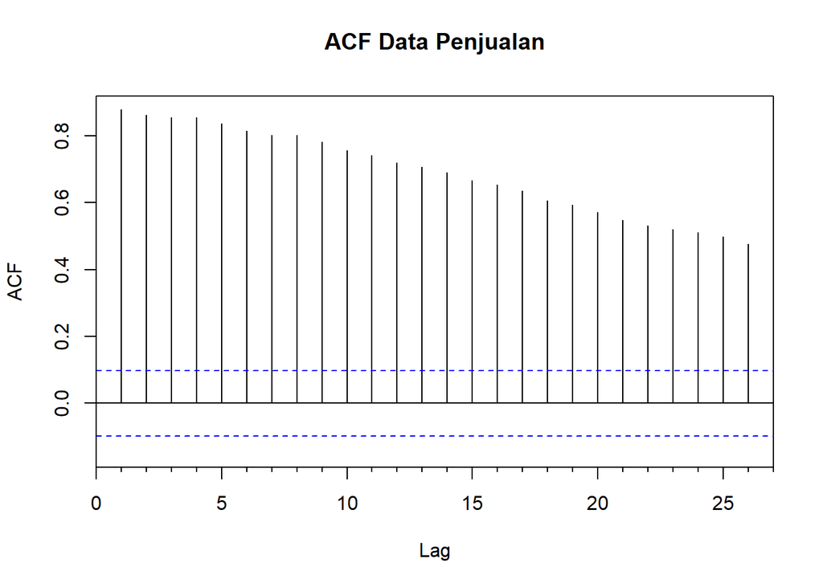

```r
Acf(DataTrain, main="ACF Data Penjualan")
```

Plot ini menunjukkan bahwa data train saya memiliki nilai autokorelasi tinggi dan **tidak stasioner** dalam rataan. Pola ini juga menunjukkan bahwa data saya berpola tails-off

## Cek rataan data train stasioner dengan Uji ADF

$H_0$ : Data train tidak stasioner dalam rataan

$H_1$ : Data train stasioner dalam rataan

```r
tseries::adf.test(DataTrain)
```

```
##
##  Augmented Dickey-Fuller Test
##
## data:  DataTrain
## Dickey-Fuller = -1.0344, Lag order = 7, p-value = 0.9325
## alternative hypothesis: stationary
```

Berdasarkan uji ADF tersebut, didapat *p-value* 0.9325 yang lebih besar dari 0.05 sehingga tak tolak $H_0$ dan menandakan bahwa data train **tidak stasioner dalam rataan** pada taraf nyata 5%. Hasil uji ini konsisten dengan hasil eksplorasi dengan plot ACF yang menunjukkan bahwa data train tidak stasioner dalam rataan.

## Cek ragam data train stasioner dengan Plot Box Cox

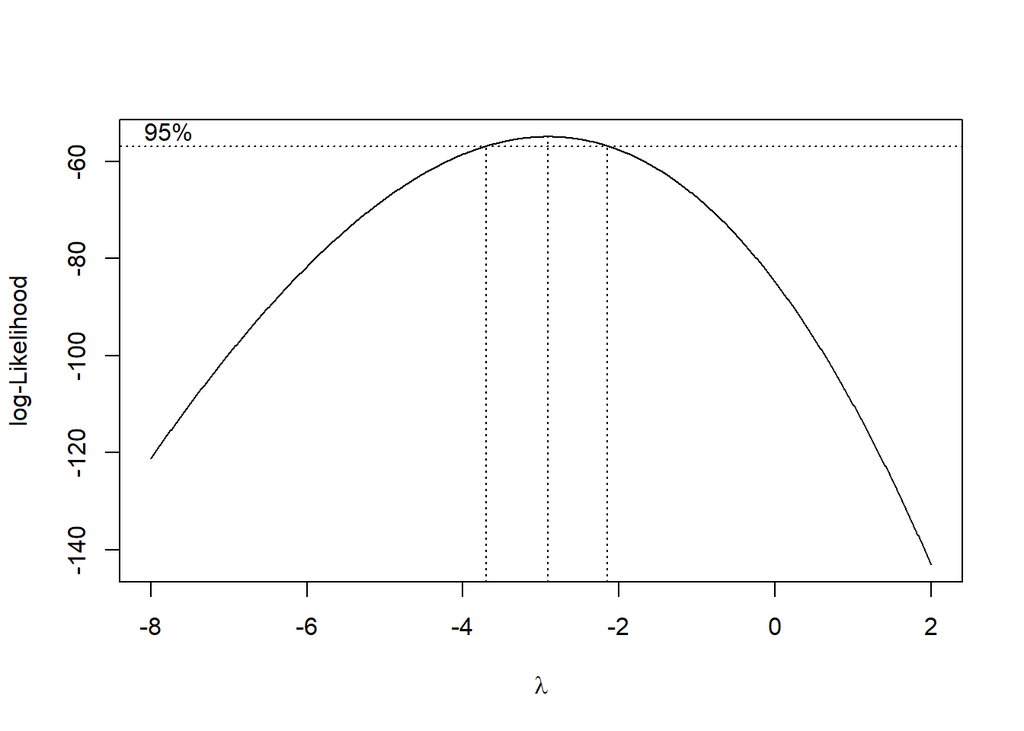

```r
index <- seq(1, 400)

# Box-Cox
bc <- boxcox(DataTrain ~ index, lambda = seq(-8, 2, by = 0.01)
)
```

```r
lambda <- bc$x[which.max(bc$y)]
lambda
```

```
## [1] -2.91
```

```r
# Selang kepercayaan 95% untuk lambda
ci_lambda <- bc$x[bc$y > max(bc$y) - 0.5 * qchisq(0.95, 1)]

# Batas bawah dan batas atas
ci_lower <- min(ci_lambda)
ci_upper <- max(ci_lambda)

c(Batas_Bawah = ci_lower, Batas_Atas = ci_upper)
```

```
## Batas_Bawah  Batas_Atas
##       -3.69       -2.15
```

Gambar di atas menunjukkan nilai λ optimum (rounded value) sebesar **-2.91** dan selang kepercayaan 95% nilai memiliki batas bawah **-3.69** dan batas atas **-2.15**. Selang tersebut tidak memuat nilai satu sehingga dapat dikatakan bahwa data train saya **tidak stasioner dalam ragam** pada taraf nyata 5%.

## Kesimpulan dari data

Data train saya **tidak stasioner dalam rataan dan tidak stasioner dalam ragam** pada taraf nyata 5%.

## Penanganan ketidak stasioneran rataan pada data train

### Differencing pertama

```r
# Differencing pertama pada DataTrain
DataTrain_diff1 <- diff(DataTrain, differences = 1)
```

#### Plot hasil differencing pertama

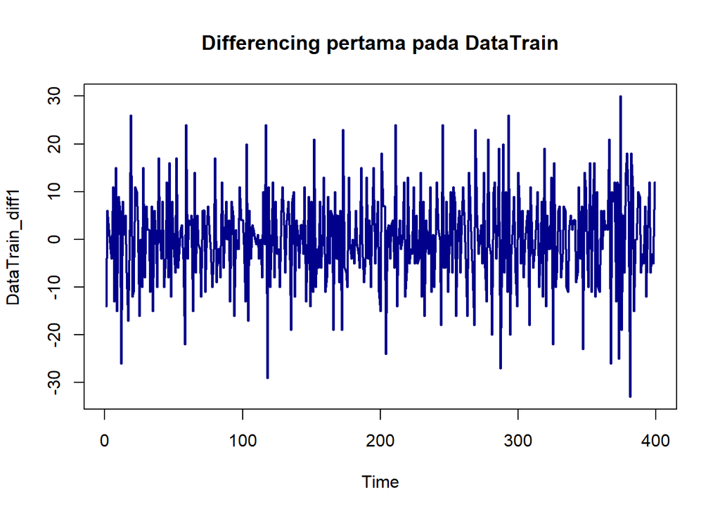

```r
ts.plot(DataTrain_diff1,
        main = "Differencing pertama pada DataTrain",
        col = "darkblue", lwd = 2)
```

Plot hasil differencing (Differencing pertama pada DataTrain) menunjukkan data train sekarang berfluktuasi di sekitar nilai nol.

Tren naik sudah hilang karena saya telah melakukan differencing orde 1.

#### Plot ACF hasil differencing pertama

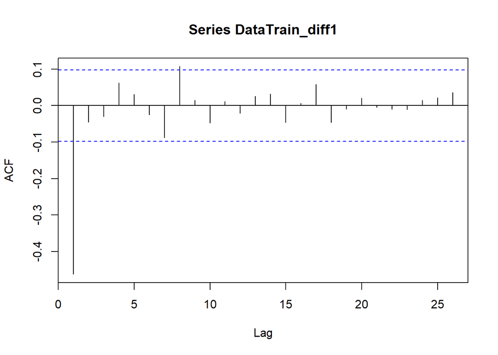

```r
acf(DataTrain_diff1)
```

Plot ACF menunjukkan korelasi yang turun tajam menuju nol setelah lag 1. Ini mengonfirmasi bahwa tren sudah berhasil dihilangkan.

#### Uji ADF hasil differencing pertama

$H_0$ : Data train hasil differencing pertama tidak stasioner dalam rataan

$H_1$ : Data train hasil differencing pertama stasioner dalam rataan

```r
tseries::adf.test(DataTrain_diff1)
```

```
##
##  Augmented Dickey-Fuller Test
##
## data:  DataTrain_diff1
## Dickey-Fuller = -10.583, Lag order = 7, p-value = 0.01
## alternative hypothesis: stationary
```

Berdasarkan uji ADF tersebut, didapat *p-value* yang lebih kecil dari 0.01 yang lebih kecil dari 0.05 sehingga tolak $H_0$ pada taraf nyata 5%. Hasil ini menandakan bahwa data train hasil differencing pertama telah **stasioner dalam rataan** pada taraf nyata 5%. Hal ini sesuai dengan hasil eksplorasi menggunakan plot time series dan plot ACF terhadap data train hasil differencing pertama.

# Permodelan ARIMA

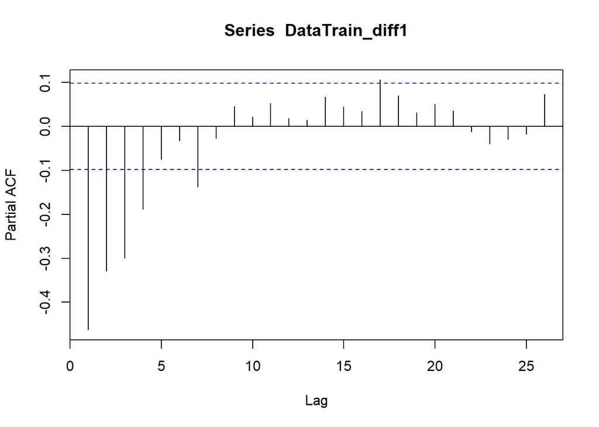

```r
pacf(DataTrain_diff1)
```

### Plot ACF

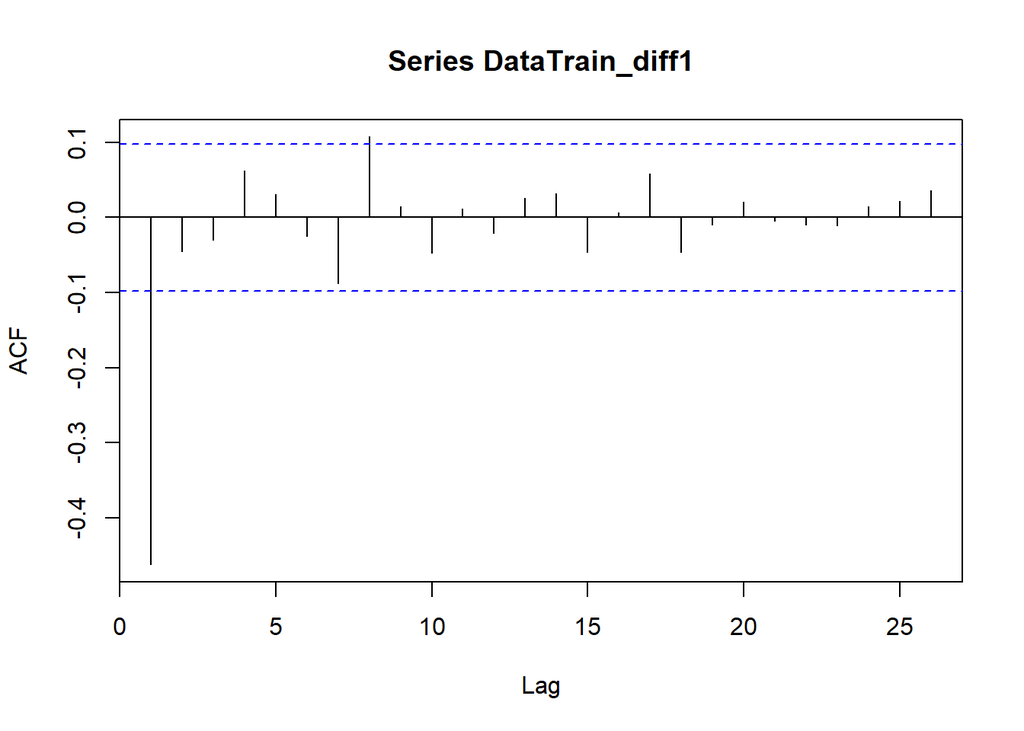

```r
acf(DataTrain_diff1)
```

### Plot EACF

```r
eacf(DataTrain_diff1)
```

```
## AR/MA
##   0 1 2 3 4 5 6 7 8 9 10 11 12 13
## 0 x o o o o o o x o o o  o  o  o
## 1 x x o o o o o o o o o  o  o  o
## 2 x x x o o o o o o o o  o  o  o
## 3 x x x x o o o o o o o  o  o  o
## 4 x o o x x o o o o o o  o  o  o
## 5 x o x x x x o o o o o  o  o  o
## 6 x x x x x x x o o o o  o  o  o
## 7 x x o x o x x o o o o  o  o  o
```

Dari plot EACF, diperoleh kandidat model ARIMA(0,1,1), ARIMA(0,1,2), dan ARIMA(1,1,2).

## Estimasi Model ARIMA dan Perbandingannya

### Model ARIMA(0,1,1)

```r
arima011 <- Arima(DataTrain, order = c(0,1,1), method="ML")
summary(arima011)
```

```
## Series: DataTrain
## ARIMA(0,1,1)
##
## Coefficients:
##           ma1
##       -0.7456
## s.e.   0.0272
##
## sigma^2 = 69.09:  log likelihood = -1411.02
## AIC=2826.03   AICc=2826.06   BIC=2834.01
##
## Training set error measures:
##                    ME     RMSE      MAE       MPE    MAPE      MASE        ACF1
## Training set 0.645866 8.291031 6.530101 0.1397114 2.96393 0.7731484 -0.03933902
```

```r
lmtest::coeftest(arima011)
```

```
##
## z test of coefficients:
##
##      Estimate Std. Error z value  Pr(>|z|)
## ma1 -0.745646   0.027204  -27.41 < 2.2e-16 ***
## ---
## Signif. codes:  0 '***' 0.001 '**' 0.01 '*' 0.05 '.' 0.1 ' ' 1
```

```r
arima012 <- Arima(DataTrain, order = c(0,1,2), method="ML")
summary(arima012)
```

```
## Series: DataTrain
## ARIMA(0,1,2)
##
## Coefficients:
##           ma1    ma2
##       -0.7917  0.050
## s.e.   0.0566  0.053
##
## sigma^2 = 69.1:  log likelihood = -1410.57
## AIC=2827.14   AICc=2827.2   BIC=2839.1
##
## Training set error measures:
##                     ME     RMSE      MAE       MPE     MAPE      MASE
## Training set 0.6356315 8.281395 6.505641 0.1361288 2.953943 0.7702525
##                      ACF1
## Training set 0.0009248647
```

```r
lmtest::coeftest(arima012)
```

```
##
## z test of coefficients:
##
##      Estimate Std. Error  z value Pr(>|z|)
## ma1 -0.791689   0.056582 -13.9918   <2e-16 ***
## ma2  0.049970   0.053034   0.9422   0.3461
## ---
## Signif. codes:  0 '***' 0.001 '**' 0.01 '*' 0.05 '.' 0.1 ' ' 1
```

```r
arima112 <- Arima(DataTrain, order = c(1,1,2), method="ML")
summary(arima112)
```

```
## Series: DataTrain
## ARIMA(1,1,2)
##
## Coefficients:
##          ar1      ma1     ma2
##       0.9083  -1.7703  0.8122
## s.e.  0.0445   0.0425  0.0358
##
## sigma^2 = 66.3:  log likelihood = -1402.11
## AIC=2812.22   AICc=2812.32   BIC=2828.18
##
## Training set error measures:
##                     ME     RMSE      MAE        MPE    MAPE      MASE
## Training set 0.3368674 8.101795 6.334584 0.03192692 2.87957 0.7499997
##                    ACF1
## Training set 0.03594317
```

```r
lmtest::coeftest(arima112)
```

```
##
## z test of coefficients:
##
##      Estimate Std. Error z value  Pr(>|z|)
## ar1  0.908342   0.044484  20.419 < 2.2e-16 ***
## ma1 -1.770288   0.042476 -41.677 < 2.2e-16 ***
## ma2  0.812238   0.035758  22.715 < 2.2e-16 ***
## ---
## Signif. codes:  0 '***' 0.001 '**' 0.01 '*' 0.05 '.' 0.1 ' ' 1
```

```r
comparison_table <- data.frame(
  Model = c("ARIMA(0,1,1)", "ARIMA(0,1,2)", "ARIMA(1,1,2)"),
  AIC = c(arima011$aic, arima012$aic, arima112$aic),
  BIC = c(arima011$bic, arima012$bic, arima112$bic)
)

comparison_table[order(comparison_table$AIC), ]
```

```
##          Model      AIC      BIC
## 3 ARIMA(1,1,2) 2812.222 2828.178
## 1 ARIMA(0,1,1) 2826.032 2834.010
## 2 ARIMA(0,1,2) 2827.138 2839.105
```

Berdasarkan signifikansi parameter dan nilai AIC, diperoleh model ARIMA(1,1,2) sebagai kandidat model terbaik untuk dilakukan peramalan lebih lanjut karena seluruh parameternya signifikan dan memiliki nilai AIC yang paling kecil.

## Evaluasi model ARIMA(1,1,2)

### Uji asumsi sisaan model ARIMA(1,1,2)

#### Uji normalitas sisaan model ARIMA(1,1,2)

$H_0$ : Sisaan menyebar normal

```
## [1]  59 381
```

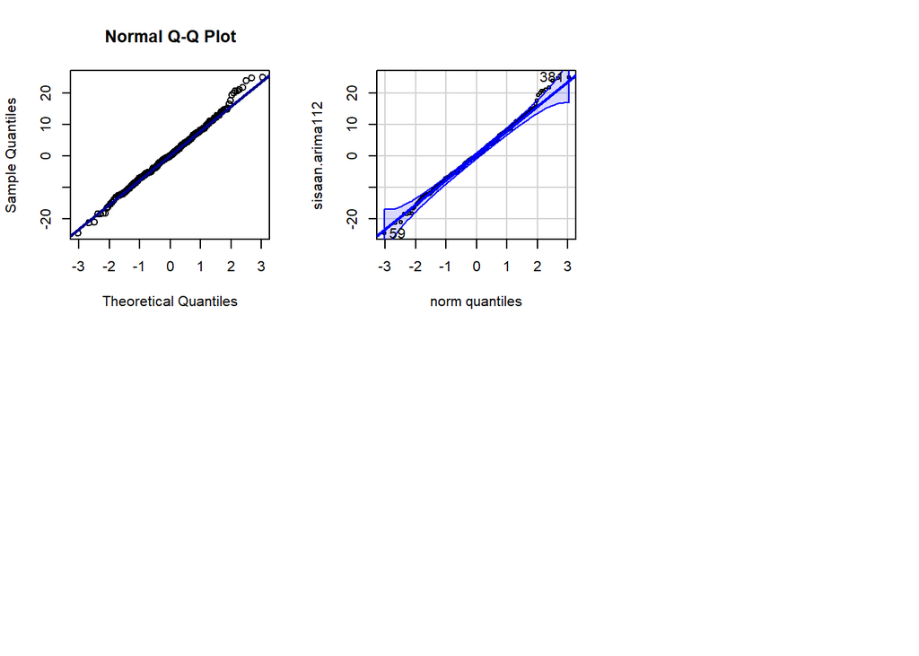

```r
#Eksplorasi
sisaan.arima112 <- arima112$residuals

par(mfrow=c(2,3))

qqnorm(sisaan.arima112)
qqline(sisaan.arima112, col = "darkblue", lwd = 2)
car::qqPlot(sisaan.arima112)
```

##### Uji Formal ktest

```r
ks.test(arima112$residuals,"pnorm")
```

```
##
##  Asymptotic one-sample Kolmogorov-Smirnov test
##
## data:  arima112$residuals
## D = 0.38448, p-value < 2.2e-16
## alternative hypothesis: two-sided
```

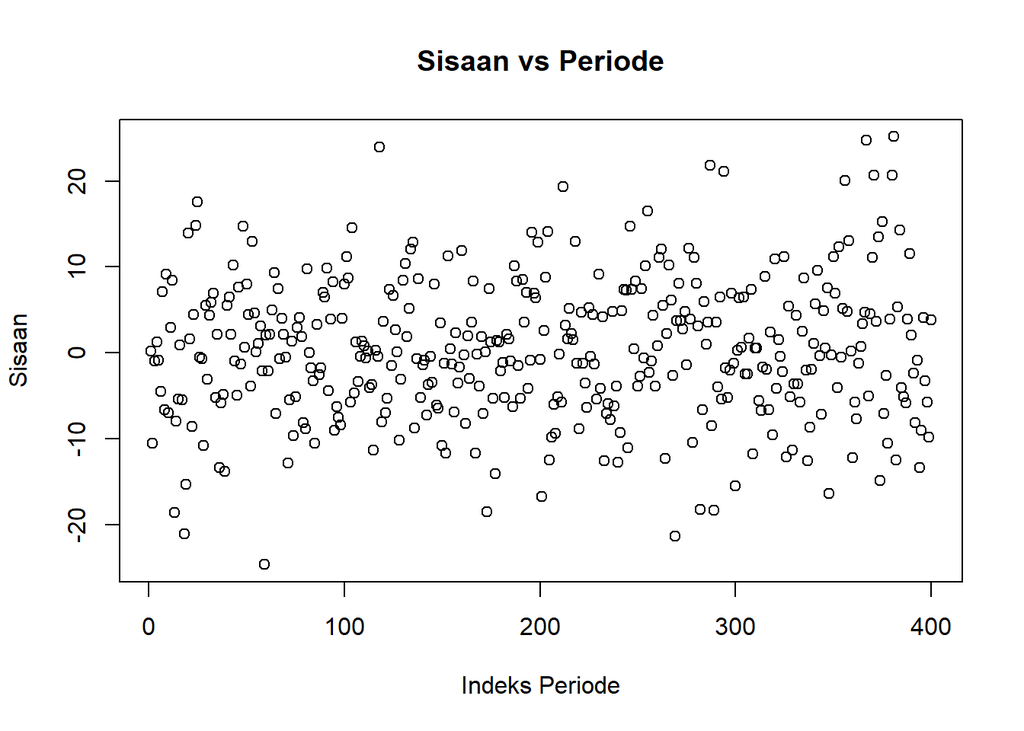

```r
par(mfrow=c(1,1))
plot(c(1:length(sisaan.arima112)), sisaan.arima112,
     main = "Sisaan vs Periode", xlab = "Indeks Periode", ylab = "Sisaan")
```

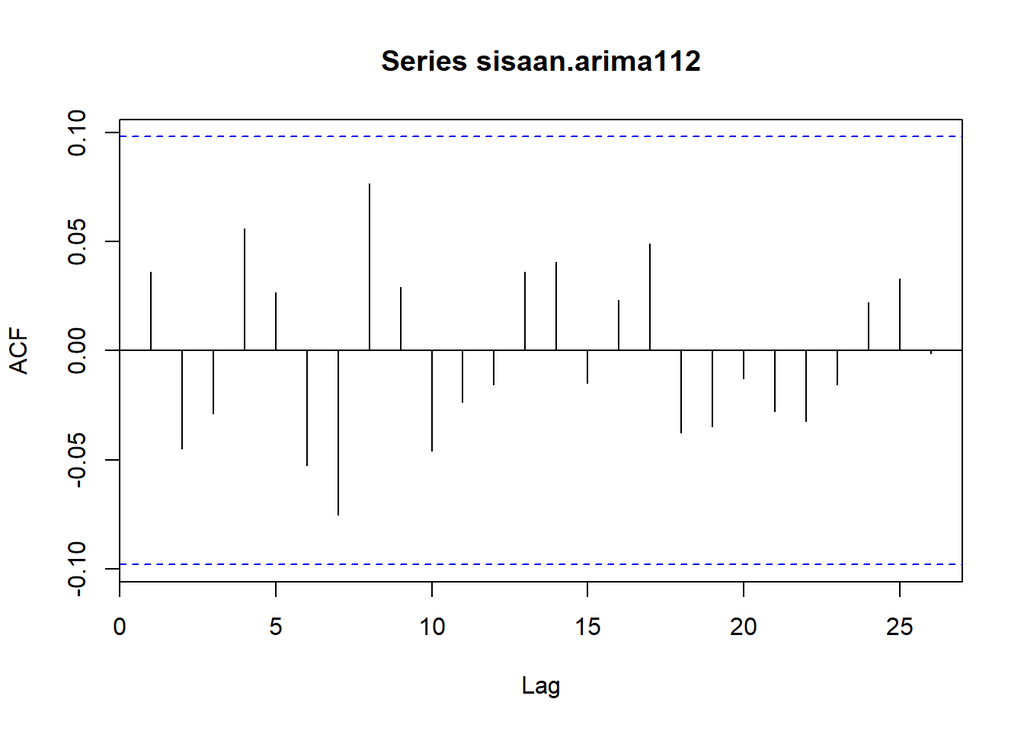

```r
# ACFF dan PACF sisaan
par(mfrow = c(1,1))
acf(sisaan.arima112)
```

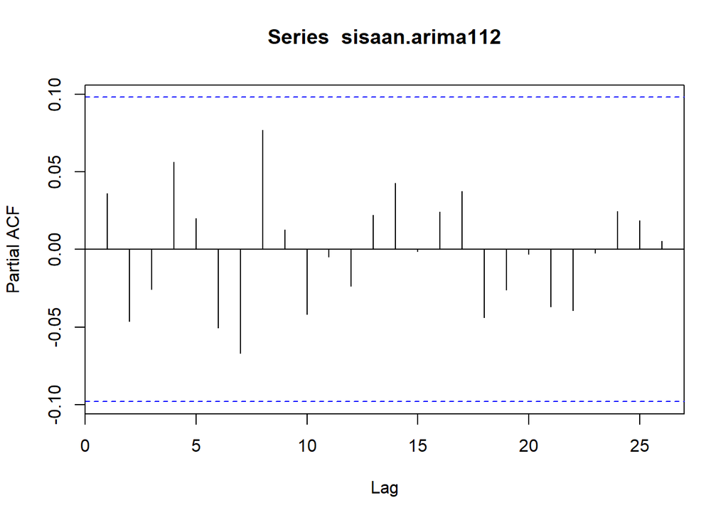

```r
pacf(sisaan.arima112)
```

##### Uji Box_Ljung

```r
Box.test((sisaan.arima112)^2, type = "Ljung")
```

```
##
##  Box-Ljung test
##
## data:  (sisaan.arima112)^2
## X-squared = 0.043033, df = 1, p-value = 0.8357
```

# Peramalan dengan model ARIMA(1,1,2)

```r
nTest = n - nTrain
ramalan <- forecast::forecast(arima112, h = nTest)
head(ramalan)
```

```
## $method
## [1] "ARIMA(1,1,2)"
##
## $model
## Series: DataTrain
## ARIMA(1,1,2)
##
## Coefficients:
##          ar1      ma1     ma2
##       0.9083  -1.7703  0.8122
## s.e.  0.0445   0.0425  0.0358
##
## sigma^2 = 66.3:  log likelihood = -1402.11
## AIC=2812.22   AICc=2812.32   BIC=2828.18
##
```

[output cut: 235 more lines]

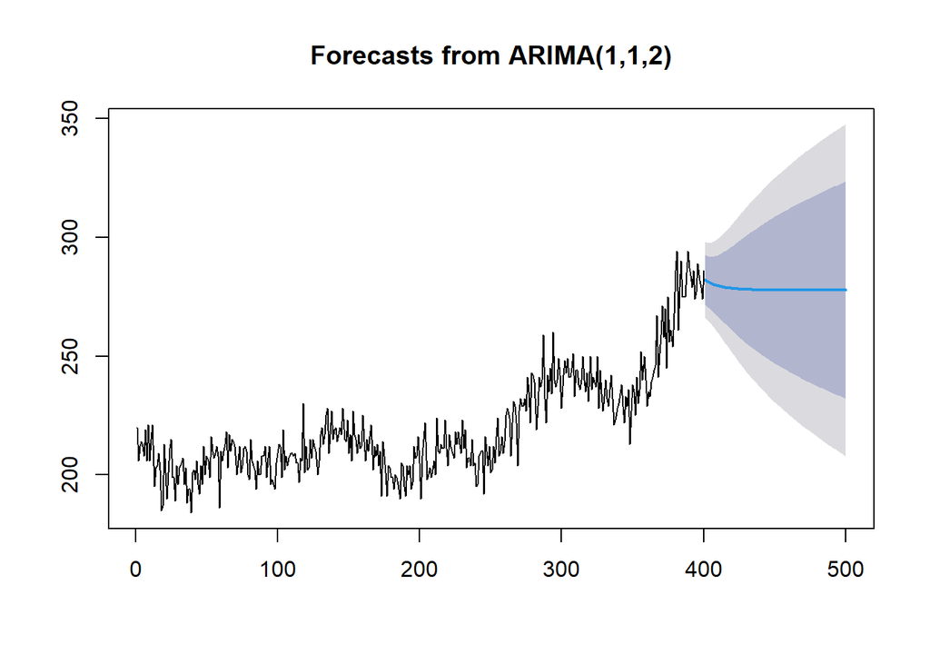

```r
data.ramalan <- ramalan$mean
plot(ramalan)
```

```r
perbandingan<-matrix(data=c(DataTest, data.ramalan),
                     nrow = nTest, ncol = 2)
colnames(perbandingan)<-c("Aktual","Hasil Forecast")
head(perbandingan)
```

```
##      Aktual Hasil Forecast
## [1,]    289       282.1146
## [2,]    267       281.7178
## [3,]    275       281.3573
## [4,]    274       281.0298
## [5,]    269       280.7324
## [6,]    266       280.4622
```

```r
accuracy(data.ramalan, DataTest)
```

```
##                ME     RMSE      MAE      MPE    MAPE
## Test set 35.25295 42.50033 37.86223 10.72073 11.6972
```